# Midterm2

b06208001 龔泓愷

2018年11月28日

# 1-2

## (1)

```r
p1 = 0.611; n1 = 131#女
p2 = 0.426; n2 = 61#男

diff = p1 - p2;diff
```

```
## [1] 0.185
```

```r
se = sqrt(p1*(1-p1)/n1 +p2*(1-p2)/n2);se
```

```
## [1] 0.07630815
```

```r
z = qnorm(0.995);z#信賴區間為雙尾
```

```
## [1] 2.575829
```

```r
#計算信賴區間
low = diff - z*se
up = diff + z*se
c(low, up)
```

```
## [1] -0.01155677  0.38155677
```

**在99%信心水準下的信賴區間為[-0.01155677, 0.38155677]**

## (2)

```r
z = qnorm(0.975);z#信賴區間為雙尾
```

```
## [1] 1.959964
```

```r
#計算信賴區間
low = diff - z*se
up = diff + z*se
c(low, up)
```

```
## [1] 0.03543878 0.33456122
```

在95%信心水準下的信賴區間為[0.03543878, 0.33456122]  
從計算結果，我們可以看出99%信心水準下的信賴區間，比起95%的信心水準下的信賴區間為廣。  
原因是在相同標準誤與兩樣本比例差的前提下，99%的Z分數較95%的Z分數為大，使其計算出的信賴區間更廣。  
也正是因為99%的較廣，我們才能有較高的信心水準來說明，母體值會落在此區間。

## (3)

**(1)計算的信賴區間包含0，也就是在99%的信心水準之下，我們無法下【針對此問題大學男女答覆的比例有差】的結論。**

# 1-3

## (1)

```r
daughter <- c(66, 64, 64, 69, 66)
mother <- c(66, 62, 65, 66, 63)
diff <- daughter - mother;diff
```

```
## [1]  0  2 -1  3  3
```

```r
dbar <- mean(diff);dbar
```

```
## [1] 1.4
```

```r
sd = sd(diff);sd
```

```
## [1] 1.81659
```

```r
n = 5


se = sd/sqrt(n);se
```

```
## [1] 0.8124038
```

```r
df = n-1
t = qt(0.975, df = df);t#信賴區間為雙尾
```

```
## [1] 2.776445
```

```r
#計算信賴區間
low = dbar - t*se
up = dbar + t*se
c(low, up)
```

```
## [1] -0.8555947  3.6555947
```

題目提供的資料為數量型(Quantitive)的成對(Paired)資料，  
因此，針對此情況，最適合的參數為：Population Mean of Paired Differences (Dependent)

**在95%信心水準下的信賴區間為[-0.8555947, 3.6555947]**

## (2)

根據(1)計算的區間，我們可以說：  
就【長遠】看來，大約有95%的機率，該區間會包含真正的母體值，  
這並非告訴我們該區間有95%的機率會包含真正的母體值。  
又該區間【包含0】，我們無法下【大學女生身高較其母親為高】的結論。

## (3)

**增加取樣數，能使計算出來的標準誤變小，最後所得的信賴區間也會變小**  
**採用較低的信心水準，使t分數變小，也能得到較小的信賴區間**

# 2

## (1)

**Step1**  
H0：此次調查比例不比0.2高，p <= 0.2  
Ha：此次調查比例比0.2高，p > 0.2

**Step2**

```r
p = 0.2; n =200
n*p
```

```
## [1] 40
```

```r
n*(1-p)
```

```
## [1] 160
```

np與n(1-p)的值皆大於10。 所以我們能使用單一母體比例的假說檢定(HT about a Population Proportion)

```r
p_hat = 50/200; p_hat
```

```
## [1] 0.25
```

```r
se = sqrt(p*(1-p)/n);se
```

```
## [1] 0.02828427
```

```r
z_value = (p_hat - p)/se;z_value
```

```
## [1] 1.767767
```

**Step3**

```r
p_value = pnorm(z_value, lower.tail = F);p_value#單尾檢定
```

```
## [1] 0.03854994
```

**Step4**  
P_value約為0.03855，小於顯著水準，我們能推翻虛無假說，接受對立假說。

**Step5**  
此樣本為統計上顯著。  
樣本提供足夠證據推翻虛無假說。  
因此，我們能下【此次調查比例比0.2高】的結論。

**所以，交通局不應該建議縣長中止BRT-B的服務**

## (2)

**Step1**  
H0：BRT-O比例(p1)不高於BRT-B的比例(p2)，p1 <= p2  
Ha：BRT-O比例(p1)高於BRT-B的比例(p2)，p1 > p2

**Step2**

```r
p1 = 60/200; n1 = 200#BRT-O
p2 = 50/200; n2 = 200#BRT-B
n1*p1;n1*(1-p1)
```

```
## [1] 60
```

```
## [1] 140
```

```r
n2*p2;n2*(1-p2)
```

```
## [1] 50
```

```
## [1] 150
```

兩群體的np與n(1-p)的值皆大於10。  
所以我們能使用兩母體比例差異的假說檢定(HT about the Difference in Two Population Proportions)

```r
p_hat <- (n1*p1 + n2*p2)/(n1 + n2);p_hat
```

```
## [1] 0.275
```

```r
se = sqrt(p_hat*(1-p_hat)/n1 + p_hat*(1-p_hat)/n2);se
```

```
## [1] 0.04465143
```

```r
z_value = ((p1 -p2) - 0)/se;z_value
```

```
## [1] 1.119785
```

**Step3**

```r
p_value <- pnorm(abs(z_value), lower.tail = F);p_value#單尾假說檢定
```

```
## [1] 0.1314027
```

**Step4**  
P_value約為0.1314，大於顯著水準，我們無法推翻虛無假說。

**Step5**  
即使此次抽樣BRT-O比例大於BRT-B，樣本卻沒有提供足夠證據推翻虛無假說。  
既然我們無法拒絕虛無假說，我們就不能下【BRT-O比例高於BRT-B的比例】的結論，  
因為我們無法拒絕【BRT-O比例不高於BRT-B的比例】的可能性。

**所以，交通局不應該建議縣長實現BRT-O的服務**

## (3)

```r
se1 <- sqrt(p1*(1-p1)/n1);se1#BRT-O
```

```
## [1] 0.0324037
```

```r
se2 <- sqrt(p2*(1-p2)/n2);se2#BRT-B
```

```
## [1] 0.03061862
```

```r
z <- qnorm(0.975);z#信賴區間是雙尾
```

```
## [1] 1.959964
```

```r
#計算信賴區間
up1 <- p1 + z*se1;up1
```

```
## [1] 0.3635101
```

```r
low1 <- p1 - z*se1;low1
```

```
## [1] 0.2364899
```

```r
up2 <- p2 + z*se2;up2
```

```
## [1] 0.3100114
```

```r
low2 <- p2 - z*se2;low2
```

```
## [1] 0.1899886
```

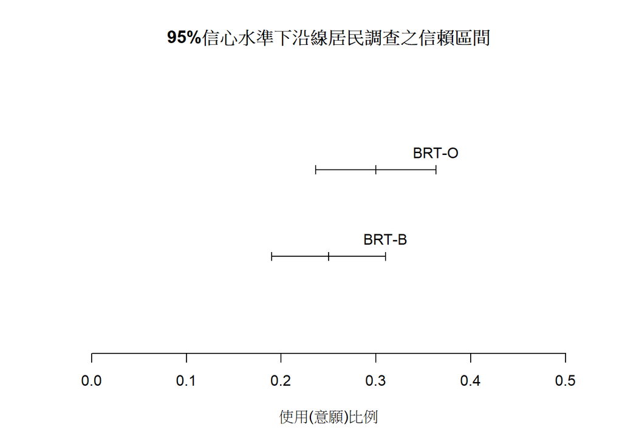

```r
#畫圖
plot(c(0,3),type='n',xlim=c(0,0.5),
     xlab='使用(意願)比例',ylab='',axes=F,
     main='95%信心水準下沿線居民調查之信賴區間')

lines(c(low1, up1),c(2,2))
text(up1,2.2,labels='BRT-O')
lines(c(low1, low1),c(1.95,2.05))
lines(c(p1, p1),c(1.95,2.05))
lines(c(up1, up1),c(1.95,2.05))

lines(c(low2, up2),c(1,1))
text(up2,1.2,labels='BRT-B')
lines(c(low2, low2),c(0.95,1.05))
lines(c(p2, p2),c(0.95,1.05))
lines(c(up2, up2),c(0.95,1.05))

axis(1)
```

此圖，我們能明顯看出兩個信賴區間有【重疊】  
因此，我們不能下【BRT-O比例高於BRT-B的比例】的結論  
因為我們不能保證【BRT-O比例不高於BRT-B的比例】是錯的  
從信賴區間的結果與(2)假說檢定的結果一致

# 3

## (1)

```r
n1 = 100; x1 = 35; sd1 = 20#使用大眾運輸
n2 = 100; x2 = 30; sd2 = 10#自行開車

#計算信賴區間
se1 <- sd1/sqrt(n1);se1#使用大眾運輸
```

```
## [1] 2
```

```r
se2 <- sd2/sqrt(n2);se2#自行開車
```

```
## [1] 1
```

```r
df = n1 - 1#兩個樣本數一樣
t <- qt(0.975, df = df);t#95%信賴區間是雙尾
```

```
## [1] 1.984217
```

```r
up1 <- x1 + t*se1
low1 <- x1 - t*se1
c(low1, up1)
```

```
## [1] 31.03157 38.96843
```

```r
up2 <- x2 + t*se2
low2 <- x2 - t*se2
c(low2, up2)
```

```
## [1] 28.01578 31.98422
```

在95%信心水準下：  
使用大眾運輸的信賴區間為[31.03157, 38.96843]  
自開車的信賴區間為[28.01578, 31.98422]

**由於信賴區間重疊(儘管只有一點)，在95%信心水準下，交通部不能宣稱台北市使用大眾運輸通勤的時間高於自行開車的通勤時間。**

## (2)

```r
#成對樣本的信賴區間
n = 100; dbar = -1; sdd = 5
sed = sdd/sqrt(n);sed
```

```
## [1] 0.5
```

```r
df = n - 1
t <- qt(0.975, df = df);t#95%信賴區間是雙尾
```

```
## [1] 1.984217
```

```r
#計算信賴區間
up <- dbar + t*sed
low <- dbar - t*sed
c(low, up)
```

```
## [1] -1.992108476 -0.007891524
```

在95%信心水準下：  
大眾運輸改善計畫前後之差信賴區間為[-1.992108476 -0.007891524]

**由於信賴區間未包含0，交通部可宣稱該計畫減少使用大眾運輸的通勤居民的通勤時間**

## (3)

### **【顯著水準】**

**Step1**  
H0：使用大眾運輸(x1)與自行開車(x2)沒有差異，x1 - x2 = 0  
Ha：使用大眾運輸(x1)與自行開車(x2)有差異，x1 - x2 != 0

```r
n1 = 100; x1 = 32.5; sd1 = 10#使用大眾運輸(新)
n2 = 100; x2 = 30; sd2 = 10#自行開車
```

**Step2**  
樣本數夠大(>=30)  
所以我們能使用兩母體平均之差的假說檢定(HT about the Difference in Two Population Means(Independent))

```r
se = sqrt(sd1^2/n1 + sd2^2/n2);se
```

```
## [1] 1.414214
```

```r
df = n1 - 1;df##兩個樣本數一樣
```

```
## [1] 99
```

```r
t_value = ((x1 - x2) - 0)/se;t_value
```

```
## [1] 1.767767
```

**Step3**

```r
p_value = pt(t_value, df = df, lower.tail = F)*2;p_value#雙尾檢定
```

```
## [1] 0.08018078
```

**Step4**  
P_value約為0.08018，大於顯著水準，我們無法推翻虛無假說。

**Step5**  
即使最新抽樣顯示兩群體平均有差異，樣本卻沒有提供足夠證據推翻虛無假說。  
既然我們無法拒絕【使用大眾運輸與自行開車沒有差異】的說法，我們就不能下【使用大眾運輸與自行開車有差異】的結論，  
因為我們無法拒絕【使用大眾運輸與自行開車沒有差異】屬實的可能性

**因此，交通部可以宣稱大眾運輸改善計畫成功讓大眾運輸通勤居民跟自行開車通勤居民之通勤時間沒有差異**

### **【效應值】**

由於兩樣本之樣本數相同，且標準差也相同，以下使用Pooled的方式計算效應值：

```r
sp = sqrt(((n1-1)*sd1^2 + (n2-1)*sd2^2)/(n1+n2-2));sp
```

```
## [1] 10
```

```r
d = (x1 - x2)/sp;d
```

```
## [1] 0.25
```

由於效應值極小(0.25)，  
根據課本說法，如此小的效應值唯有使用統計才有辦法察覺，一般人難以發現。  
因此，交通部可以宣稱大眾運輸改善計畫成功讓大眾運輸通勤居民跟自行開車通勤居民之通勤時間沒有差異

# 4

## (1)

```r
data <- read.csv('pennstate2.csv')
head(data)
```

```
##   s e t  c  h h.1 l f
## 1 F 2 N 25 70  70 4 O
## 2 M 0 N 47 77  77 6 N
## 3 M 2 N 50 71  71 5 O
## 4 F 2 N 50 65  65 4 O
## 5 M 4 Y 50 74  72 5 N
## 6 F 9 Y 70 61  65 7 O
```

藉由查詢的方式，取得各性別的運動資料：

```r
library(dplyr)

FY = nrow(filter(data, s =='F', t == 'Y'));FY#女生有運動
```

```
## [1] 18
```

```r
FN = nrow(filter(data, s =='F', t == 'N'));FN#女生沒運動
```

```
## [1] 119
```

```r
MY = nrow(filter(data, s =='M', t == 'Y'));MY#男生有運動
```

```
## [1] 13
```

```r
MN = nrow(filter(data, s =='M', t == 'N'));MN#男生沒運動
```

```
## [1] 55
```

```r
FY + FN + MY + MN#確認總和為205
```

```
## [1] 205
```

```r
p_exercise = (FY + MY)/205;p_exercise#該校運動比例
```

```
## [1] 0.1512195
```

```r
se = sqrt(p_exercise*(1-p_exercise)/205);se
```

```
## [1] 0.02502215
```

```r
#計算信賴區間
z = qnorm(0.975);z
```

```
## [1] 1.959964
```

```r
low = p_exercise - z*se
up = p_exercise + z*se
c(low, up)
```

```
## [1] 0.102177 0.200262
```

在95%的信心水準下，信賴區間為[0.102177, 0.200262]

**由於信賴區間並沒有完全落在宣稱值之上，調查結果不支持該項宣稱**

## (2)

```r
p1 = MY/(MN + MY);p1#男生運動比例
```

```
## [1] 0.1911765
```

```r
p2 = FY/(FN + FY);p2#女生運動比例
```

```
## [1] 0.1313869
```

```r
se1 <- sqrt(p1*(1-p1)/(MN + MY));se1
```

```
## [1] 0.04768586
```

```r
se2 <- sqrt(p2*(1-p2)/(FN + FY));se2
```

```
## [1] 0.02886216
```

```r
z <- qnorm(0.975);z#95%信賴區間是雙尾
```

```
## [1] 1.959964
```

```r
#計算信賴區間
up1 <- p1 + z*se1
low1 <- p1 - z*se1
up2 <- p2 + z*se2
low2 <- p2 - z*se2
c(low1, up1)
```

```
## [1] 0.0977139 0.2846390
```

```r
c(low2, up2)
```

```
## [1] 0.07481806 0.18795566
```

在95%的信心水準下：  
男生運動信賴區間為[0.0977139, 0.2846390]  
女生運動信賴區間為[0.07481806, 0.18795566]

**由於兩個信賴區間重疊，該調查無法支持校方男同學每周運動達標比例高於女同學**